# S2MET Predictions Analysis

#### Homogenous Variance

The following models will operate under the assumption of homogeneous genetic variance across environment.

##### Normal G-BLUP Model

With this framework established, we will first predict using the regular G-BLUP model

$$\mathbf{y} = \mathbf{X \beta} + \mathbf{Zg} + \mathbf{e}$$

We will restrict our predictions to a single environment in all cases

Now for each validation environment, use all training data except that environment

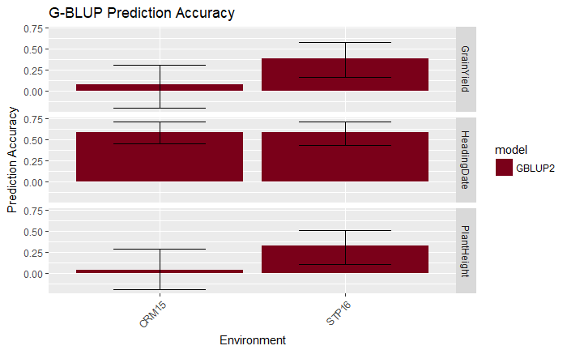

##### Addtive GE-BLUP Model

These models will account for the random environmental effect (using the environmental relationship matrix), but will not include interaction.

$$\mathbf{y} = \mathbf{X \beta} + \mathbf{Zg} + \mathbf{Wt} + \mathbf{e}$$

Here we will only use the procedure where all training environments (minus the prediction environment) are used to predict that prediction environment.

```r
# Load
load_file <- file.path(pred_dir, "Results/aGEBLUP_results.RData")
load(load_file)
# Perform a bootstrap correlation and plot
a_geblup2_analysis <- a_geblup2_results %>%
  unnest() %>%
  unnest() %>%
  group_by(environment, trait) %>%
  do({pred_acc = boot_cor(x = .$value, y = .$pred, boot.reps = 1000)}) %>%
  mutate(model = "aGEBLUP2") %>%
  dplyr::select(model, environment, trait, names(.))
```

```
|=========================================================================================|100% ~0 s remaining
```

##### Interaction GE-BLUP Model

These models will account for the random environmental effect (using the environmental relationship matrix) and random interaction between genotype and environment

$$\mathbf{y} = \mathbf{X \beta} + \mathbf{Zg} + \mathbf{Wt} + \mathbf{Uq} + \mathbf{e}$$

Here we will only use the procedure where all training environments (minus the prediction environment) are used to predict that prediction environment.

```r
# Perform a bootstrap correlation and plot
i_geblup2_analysis <- i_geblup2_results %>%
  unnest() %>%
  unnest() %>%
  group_by(environment, trait) %>%
  do({pred_acc = boot_cor(x = .$value, y = .$pred, boot.reps = 1000)}) %>%
  mutate(model = "iGEBLUP2") %>%
  dplyr::select(model, environment, trait, names(.))
```

```
|=========================================================================================|100% ~0 s remaining
```

Plot analyses

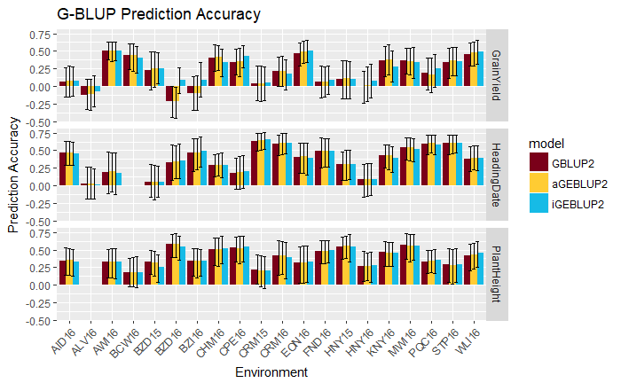

#### Heterogenous Variance Models

The following models will assume that the genetic variance (i.e. $\sigma^2_G$) is different in each environment. These model are also known as a diagonal model

##### Normal G BLUP

```r
# Iterate over all traits
gblup2_diag_results <- expand.grid(environment = env_pred, trait = traits, stringsAsFactors = FALSE) %>%
  group_by(environment, trait) %>%
  do(pred_out = {

    env <- .$environment

    # Training and prediction phenotypes
    pheno_train <- filter(pheno, environment != env, trait == .$trait) %>%
      droplevels() %>%
      filter(line_name %in% tp)
    pheno_pred <- filter(pheno, line_name %in% vp, environment == env, trait == .$trait)

    solve_out <- mmer2(fixed = value ~ 1 + environment, random = ~ at(environment):g(line_name),
                       rcov = ~at(environment):units, data = pheno_train, G = list(line_name = G))

    # Extract random effects
    ranefs <- randef(solve_out) })
```

## Appendix A

Compare two methods of design / covariances matrices

Use data from 2 environments to train, 1 to predict

```r
# Assign training and prediction environments
env_train <- sort(c("STP16", "CRM16"))
env_pred <- c("FND16")

# Only use height data
pheno_use <- pheno %>%
  filter(trait == "PlantHeight")

# Pull out the phenotypic data
pheno_train <- pheno_use %>%
  filter(environment %in% env_train, line_name %in% tp)
pheno_pred <- pheno_use %>%
  filter(environment %in% env_pred, line_name %in% vp)


# Create the incidence matrix for the genotypes
Z_g <- model.matrix(~ -1 + line_name, data = pheno_train)
# Same for environments
Z_e <- model.matrix(~ -1 + environment, data = pheno_train)
```

Jarquín, Diego, Kyle Kocak, Luis Posadas, Katie Hyma, Joseph Jedlicka, George Graef, and Aaron Lorenz. 2014. “Genotyping by sequencing for genomic prediction in a soybean breeding population.” *BMC Genomics* 15 (1): 740. doi:10.1186/1471-2164-15-740.

VanRaden, P.M. 2008. “Efficient Methods to Compute Genomic Predictions.” *Journal of Dairy Science* 91 (11). Elsevier: 4414–23. doi:10.3168/jds.2007-0980.